# COMPSCIX 415.2 Homework 7

Lian Shen

March 12, 2019

Load libraries

```r
library(tidyverse)
library(broom)
```

## **Exercise 1**

**Load the train.csv dataset into R. How many observations and columns are there?**

```r
filepath <- "C:\\Users\\lshen\\Documents\\Data Science\\train.csv"
train_data <- read_csv(file = filepath)
glimpse(train_data)
```

```
## Observations: 1,460
## Variables: 81
## $ Id            <dbl> 1, 2, 3, 4, 5, 6, 7, 8, 9, 10, 11, 12, 13, 14, 1...
## $ MSSubClass    <dbl> 60, 20, 60, 70, 60, 50, 20, 60, 50, 190, 20, 60,...
## $ MSZoning      <chr> "RL", "RL", "RL", "RL", "RL", "RL", "RL", "RL", ...
## $ LotFrontage   <dbl> 65, 80, 68, 60, 84, 85, 75, NA, 51, 50, 70, 85, ...
## $ LotArea       <dbl> 8450, 9600, 11250, 9550, 14260, 14115, 10084, 10...
## $ Street        <chr> "Pave", "Pave", "Pave", "Pave", "Pave", "Pave", ...
## $ Alley         <chr> NA, NA, NA, NA, NA, NA, NA, NA, NA, NA, NA, NA, ...
## $ LotShape      <chr> "Reg", "Reg", "IR1", "IR1", "IR1", "IR1", "Reg",...
## $ LandContour   <chr> "Lvl", "Lvl", "Lvl", "Lvl", "Lvl", "Lvl", "Lvl",...
## $ Utilities     <chr> "AllPub", "AllPub", "AllPub", "AllPub", "AllPub"...
## $ LotConfig     <chr> "Inside", "FR2", "Inside", "Corner", "FR2", "Ins...
## $ LandSlope     <chr> "Gtl", "Gtl", "Gtl", "Gtl", "Gtl", "Gtl", "Gtl",...
## $ Neighborhood  <chr> "CollgCr", "Veenker", "CollgCr", "Crawfor", "NoR...
```

[output cut: 68 more lines]

There are 1,460 observations and 81 variables.

## **Exercise 2**

**Normally at this point you would spend a few days on EDA, but for this homework we will do some very basic EDA and get right to fitting some linear regression models.**  
**Our target will be `SalePrice`.**  
**• Visualize the distribution of `SalePrice`.**

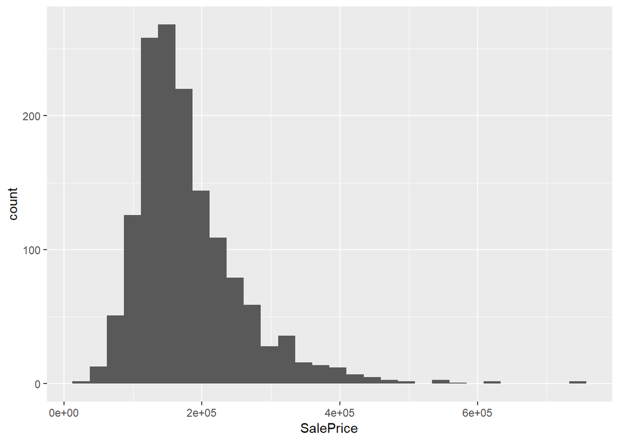

```r
train_data %>% ggplot(aes(x = SalePrice)) + geom_histogram()
```

**• Visualize the covariation between `SalePrice` and `Neighborhood`.**

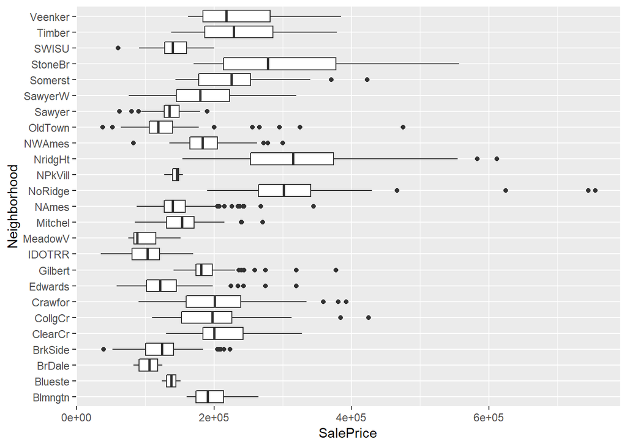

```r
train_data %>% ggplot(aes(x = Neighborhood, y = SalePrice)) + geom_boxplot() + coord_flip()
```

**• Visualize the covariation between `SalePrice` and `OverallQual`.**

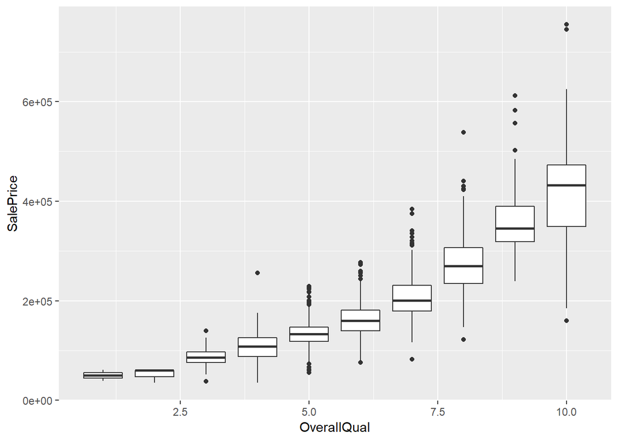

```r
train_data %>% ggplot(aes(x = OverallQual, y = SalePrice)) + geom_boxplot(aes(group = cut_width(OverallQual, 1)))
```

## **Exercise 3**

**Our target is called `SalePrice`. First, we can fit a simple regression model consisting of only the intercept (the average of `SalePrice`). Fit the model and then use the `broom` package to**  
**• take a look at the coefficient,**  
**• compare the coefficient to the average value of `SalePrice`, and** The coefficient is 180921.2 which is the same as the mean `SalePrice`  
**• take a look at the R-squared.** The R-squared value is 0 because we are not fitting the model to an independent variable. This coincides with the formula for R-squared = 1 - (sum of squared residuals)/(total sum of squares). In this case the model’s sum of squared residuals is the same as the total sum of squares so 1 - SS/SS = 0.

```r
train_data <- train_data %>% mutate(average_SalePrice = mean(SalePrice))
first(train_data$average_SalePrice)
```

```
## [1] 180921.2
```

```r
saleprice_lm <- lm(formula = SalePrice ~ average_SalePrice, data = train_data)
tidy(saleprice_lm)
```

```
## # A tibble: 1 x 5
##   term        estimate std.error statistic p.value
##   <chr>          <dbl>     <dbl>     <dbl>   <dbl>
## 1 (Intercept)  180921.     2079.      87.0       0
```

```r
glance(saleprice_lm)
```

```
## # A tibble: 1 x 11
##   r.squared adj.r.squared  sigma statistic p.value    df  logLik    AIC
##       <dbl>         <dbl>  <dbl>     <dbl>   <dbl> <int>   <dbl>  <dbl>
## 1         0             0 79443.        NA      NA     1 -18544. 37092.
## # ... with 3 more variables: BIC <dbl>, deviance <dbl>, df.residual <int>
```

## **Exercise 4**

**Now fit a linear regression model using `GrLivArea`, `OverallQual`, and `Neighborhood` as the features. Don’t forget to look at `data_description.txt` to understand what these variables mean. Ask yourself these questions before fitting the model:**  
**• What kind of relationship will these features have with our target?** `SalePrice` may increase with increasing `GrLivArea` (which is above ground living area square feet). `SalePrice` may also increase with `OverallQual`. The relationship between `SalePrice` and `Neighborhood` will be harder to identify, but generally a nicer neighborhood would correlate with higher `SalePrice`.  
**• Can the relationship be estimated linearly?** Potentially, but the relationship may not actually be linear.  
**• Are these good features, given the problem we are trying to solve?** These features may correlate with `SalePrice`.  
**After fitting the model, output the coefficients and the R-squared using the `broom` package.**

```r
train_data <- train_data %>% mutate(neighborhood_factor = factor(train_data$Neighborhood))
saleprice_lm <- lm(formula = SalePrice ~ GrLivArea + OverallQual + Neighborhood, data = train_data)
tidy(saleprice_lm)
```

```
## # A tibble: 27 x 5
##    term                estimate std.error statistic  p.value
##    <chr>                  <dbl>     <dbl>     <dbl>    <dbl>
##  1 (Intercept)         -34829.   11541.       -3.02 2.59e- 3
##  2 GrLivArea               55.6      2.50     22.2  2.38e-94
##  3 OverallQual          20951.    1162.       18.0  1.24e-65
##  4 NeighborhoodBlueste -30753.   27697.       -1.11 2.67e- 1
##  5 NeighborhoodBrDale  -43359.   12979.       -3.34 8.57e- 4
##  6 NeighborhoodBrkSide -13025.   10450.       -1.25 2.13e- 1
##  7 NeighborhoodClearCr  24576.   11570.        2.12 3.38e- 2
##  8 NeighborhoodCollgCr  11414.    9497.        1.20 2.30e- 1
##  9 NeighborhoodCrawfor  14444.   10502.        1.38 1.69e- 1
## 10 NeighborhoodEdwards -17843.    9986.       -1.79 7.42e- 2
## # ... with 17 more rows
```

```r
levels(train_data$neighborhood_factor)
```

```
##  [1] "Blmngtn" "Blueste" "BrDale"  "BrkSide" "ClearCr" "CollgCr" "Crawfor"
##  [8] "Edwards" "Gilbert" "IDOTRR"  "MeadowV" "Mitchel" "NAmes"   "NoRidge"
## [15] "NPkVill" "NridgHt" "NWAmes"  "OldTown" "Sawyer"  "SawyerW" "Somerst"
## [22] "StoneBr" "SWISU"   "Timber"  "Veenker"
```

**Answer these questions:**  
**• How would you interpret the coefficients on `GrLivArea` and `OverallQual`?** The variables `GrLivArea` and `OverallQual` have a positive linear trend with `SalePrice`. With increasing `GrLivarea` and `OverallQual`, `SalePrice` increases.  
**• How would you interpret the coefficient on `NeighborhoodBrkSide`?** BrkSide is selling about $13,025.4529 less than Blmgtn (which is the reference factor for Neighborhood).  
**• Are the features significant?** `GrLivArea` and `OverallQual` seem significant since the p-value is less than 0.05, so they seem significantly different than 0. `Neighborhood` doesn’t seem as significant with its p-value fluctuating below and above 0.05. **• Are the features practically significant?** `GrLivArea` and `OverallQual` seem to be practically significant. For every one unit increase in living area square feet, the `SalePrice` increases by $55.56. For every one unit increase in `OverallQual` the `SalePrice` increases by $20,951.42 (which at first seems like a large amount, but after comparing the `SalePrice` range 0:700,000 to the `OverallQual` range 1:10, the unit increase makes sense, from Exercise 2). `Neighborhood` is harder to tell if it is practically significant since we don’t really have an understanding of each of the neighborhood’s conditions to compare to the reference neighborhood Blmgtn.  
**• Is the model a good fit?** The model is generally a good fit with the adjusted r-squared value being 78.3%, meaning 78.3% of the model’s variability can be explained by the features.

```r
glance(saleprice_lm)
```

```
## # A tibble: 1 x 11
##   r.squared adj.r.squared  sigma statistic p.value    df  logLik    AIC
##       <dbl>         <dbl>  <dbl>     <dbl>   <dbl> <int>   <dbl>  <dbl>
## 1     0.787         0.783 37009.      203.       0    27 -17416. 34887.
## # ... with 3 more variables: BIC <dbl>, deviance <dbl>, df.residual <int>
```

## **Exercise 5**

**Feel free to play around with linear regression. Add some other features and see how the model results change.**

LotArea: Lot size in square feet  
OverallQual: Rates the overall material and finish of the house  
OverallCond: Rates the overall condition of the house  
YearBuilt: Original construction date

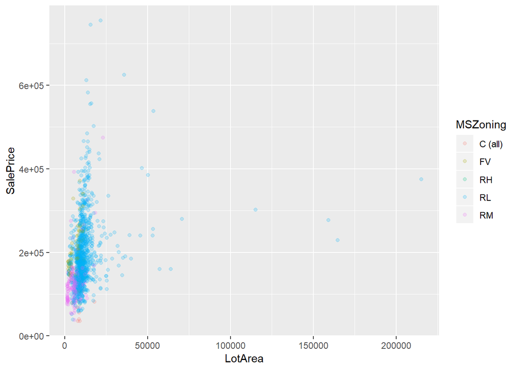

```r
train_data %>% ggplot(aes(x = LotArea, y = SalePrice, color = MSZoning)) + geom_point(alpha = 0.2)
```

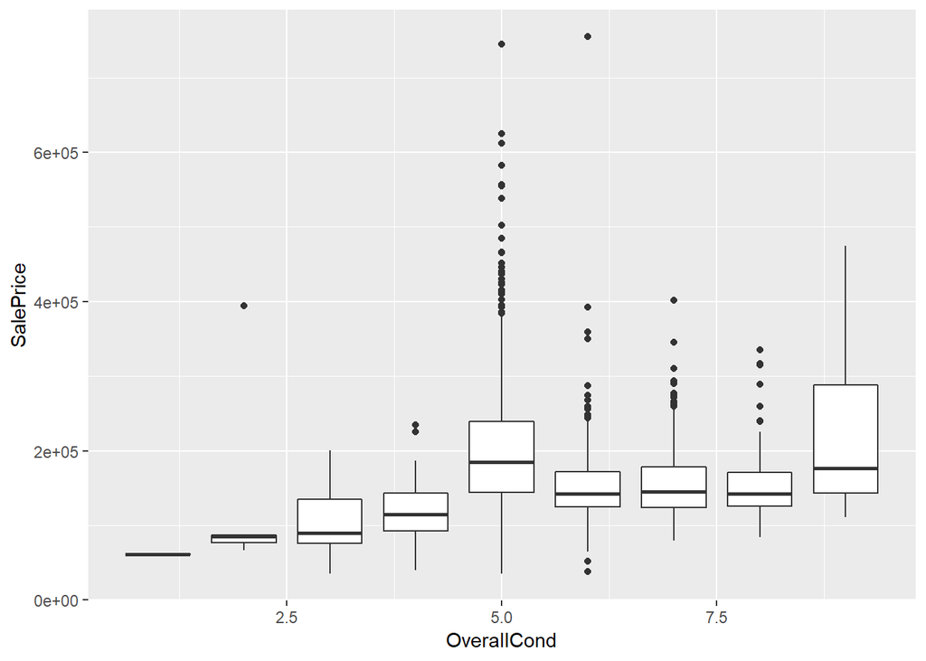

```r
train_data %>% ggplot(aes(x = OverallCond, y = SalePrice)) + geom_boxplot(aes(group = cut_width(OverallCond, 1)))
```

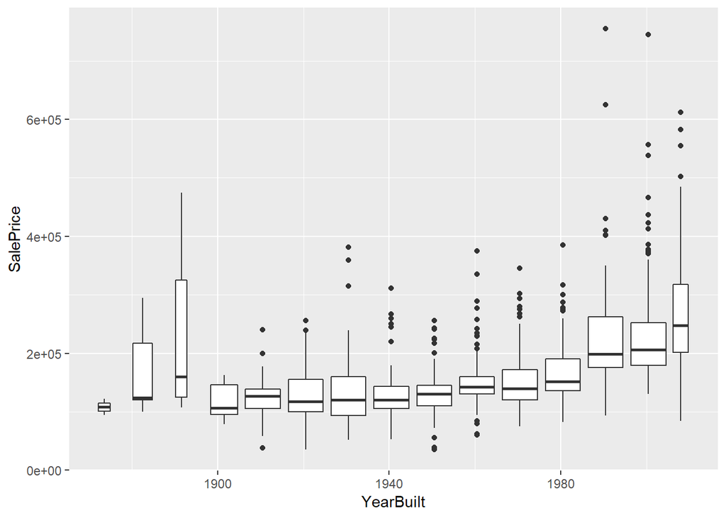

```r
train_data %>% ggplot(aes(x = YearBuilt, y = SalePrice)) + geom_boxplot(aes(group = cut_width(YearBuilt, 10)))
```

```r
test_lm <- lm(SalePrice ~ LotArea + OverallCond + YearBuilt, data = train_data)
tidy(test_lm)
```

```
## # A tibble: 4 x 5
##   term           estimate  std.error statistic   p.value
##   <chr>             <dbl>      <dbl>     <dbl>     <dbl>
## 1 (Intercept) -2857704.   121414.       -23.5  4.54e-104
## 2 LotArea            2.04      0.167     12.2  1.27e- 32
## 3 OverallCond     9879.     1621.         6.10 1.40e-  9
## 4 YearBuilt       1503.       59.7       25.2  2.73e-116
```

```r
glance(test_lm)
```

```
## # A tibble: 1 x 11
##   r.squared adj.r.squared  sigma statistic   p.value    df  logLik    AIC
##       <dbl>         <dbl>  <dbl>     <dbl>     <dbl> <int>   <dbl>  <dbl>
## 1     0.356         0.354 63837.      268. 2.07e-138     4 -18223. 36456.
## # ... with 3 more variables: BIC <dbl>, deviance <dbl>, df.residual <int>
```

```r
test_lm <- lm(SalePrice ~ LotArea + OverallQual + OverallCond + YearBuilt, data = train_data)
tidy(test_lm)
```

```
## # A tibble: 5 x 5
##   term          estimate  std.error statistic   p.value
##   <chr>            <dbl>      <dbl>     <dbl>     <dbl>
## 1 (Intercept) -798414.   103242.        -7.73 1.94e- 14
## 2 LotArea           1.50      0.121     12.4  1.27e- 33
## 3 OverallQual   40028.     1079.        37.1  1.17e-212
## 4 OverallCond    2736.     1178.         2.32 2.03e-  2
## 5 YearBuilt       357.       52.8        6.77 1.90e- 11
```

```r
glance(test_lm)
```

```
## # A tibble: 1 x 11
##   r.squared adj.r.squared  sigma statistic p.value    df  logLik    AIC
##       <dbl>         <dbl>  <dbl>     <dbl>   <dbl> <int>   <dbl>  <dbl>
## 1     0.669         0.668 45773.      735.       0     5 -17737. 35486.
## # ... with 3 more variables: BIC <dbl>, deviance <dbl>, df.residual <int>
```

## **Exercise 6**

**One downside of the linear model is that it is sensitive to unusual values because the distance incorporates a squared term. Fit a linear model to the simulated data below (use y as the target and x as the feature), and look at the resulting coefficients and R-squared. Rerun it about 5-6 times to generate different simulated datasets. What do you notice about the model’s coefficient on x and the R-squared values?**

```r
sim1a <- tibble(x = rep(1:10, each = 3),y = x * 1.5 + 6 + rt(length(x), df = 2))
sim_lm <- lm(y ~ x, data = sim1a)
tidy(sim_lm)
```

```
## # A tibble: 2 x 5
##   term        estimate std.error statistic      p.value
##   <chr>          <dbl>     <dbl>     <dbl>        <dbl>
## 1 (Intercept)     5.09     1.44       3.53 0.00146
## 2 x               1.82     0.233      7.82 0.0000000161
```

```r
glance(sim_lm)
```

```
## # A tibble: 1 x 11
##   r.squared adj.r.squared sigma statistic p.value    df logLik   AIC   BIC
##       <dbl>         <dbl> <dbl>     <dbl>   <dbl> <int>  <dbl> <dbl> <dbl>
## 1     0.686         0.675  3.66      61.2 1.61e-8     2  -80.5  167.  171.
## # ... with 2 more variables: deviance <dbl>, df.residual <int>
```

```r
sim1a1 <- tibble(x = rep(1:10, each = 3),y = x * 1.5 + 6 + rt(length(x), df = 2))
sim_lm1 <- lm(y ~ x, data = sim1a1)
sim1a2 <- tibble(x = rep(1:10, each = 3),y = x * 1.5 + 6 + rt(length(x), df = 2))
sim_lm2 <- lm(y ~ x, data = sim1a2)
sim1a3 <- tibble(x = rep(1:10, each = 3),y = x * 1.5 + 6 + rt(length(x), df = 2))
sim_lm3 <- lm(y ~ x, data = sim1a3)
sim1a4 <- tibble(x = rep(1:10, each = 3),y = x * 1.5 + 6 + rt(length(x), df = 2))
sim_lm4 <- lm(y ~ x, data = sim1a4)
sim1a5 <- tibble(x = rep(1:10, each = 3),y = x * 1.5 + 6 + rt(length(x), df = 2))
sim_lm5 <- lm(y ~ x, data = sim1a5)

tidy(sim_lm1)
```

```
## # A tibble: 2 x 5
##   term        estimate std.error statistic      p.value
##   <chr>          <dbl>     <dbl>     <dbl>        <dbl>
## 1 (Intercept)     8.29     1.03       8.01 0.0000000101
## 2 x               1.19     0.167      7.13 0.0000000927
```

```r
glance(sim_lm1)
```

```
## # A tibble: 1 x 11
##   r.squared adj.r.squared sigma statistic p.value    df logLik   AIC   BIC
##       <dbl>         <dbl> <dbl>     <dbl>   <dbl> <int>  <dbl> <dbl> <dbl>
## 1     0.645         0.632  2.62      50.9 9.27e-8     2  -70.5  147.  151.
## # ... with 2 more variables: deviance <dbl>, df.residual <int>
```

```r
tidy(sim_lm2)
```

```
## # A tibble: 2 x 5
##   term        estimate std.error statistic  p.value
##   <chr>          <dbl>     <dbl>     <dbl>    <dbl>
## 1 (Intercept)     5.71    0.549       10.4 4.04e-11
## 2 x               1.49    0.0885      16.8 3.46e-16
```

```r
glance(sim_lm2)
```

```
## # A tibble: 1 x 11
##   r.squared adj.r.squared sigma statistic  p.value    df logLik   AIC   BIC
##       <dbl>         <dbl> <dbl>     <dbl>    <dbl> <int>  <dbl> <dbl> <dbl>
## 1     0.910         0.907  1.39      284. 3.46e-16     2  -51.5  109.  113.
## # ... with 2 more variables: deviance <dbl>, df.residual <int>
```

```r
tidy(sim_lm3)
```

```
## # A tibble: 2 x 5
##   term        estimate std.error statistic  p.value
##   <chr>          <dbl>     <dbl>     <dbl>    <dbl>
## 1 (Intercept)     4.57     0.773      5.92 2.29e- 6
## 2 x               1.87     0.125     15.0  6.73e-15
```

```r
glance(sim_lm3)
```

```
## # A tibble: 1 x 11
##   r.squared adj.r.squared sigma statistic  p.value    df logLik   AIC   BIC
##       <dbl>         <dbl> <dbl>     <dbl>    <dbl> <int>  <dbl> <dbl> <dbl>
## 1     0.889         0.885  1.96      224. 6.73e-15     2  -61.7  129.  134.
## # ... with 2 more variables: deviance <dbl>, df.residual <int>
```

```r
tidy(sim_lm4)
```

```
## # A tibble: 2 x 5
##   term        estimate std.error statistic  p.value
##   <chr>          <dbl>     <dbl>     <dbl>    <dbl>
## 1 (Intercept)     5.89    0.391       15.1 5.82e-15
## 2 x               1.49    0.0630      23.7 4.44e-20
```

```r
glance(sim_lm4)
```

```
## # A tibble: 1 x 11
##   r.squared adj.r.squared sigma statistic  p.value    df logLik   AIC   BIC
##       <dbl>         <dbl> <dbl>     <dbl>    <dbl> <int>  <dbl> <dbl> <dbl>
## 1     0.953         0.951 0.991      562. 4.44e-20     2  -41.3  88.5  92.7
## # ... with 2 more variables: deviance <dbl>, df.residual <int>
```

```r
tidy(sim_lm5)
```

```
## # A tibble: 2 x 5
##   term        estimate std.error statistic   p.value
##   <chr>          <dbl>     <dbl>     <dbl>     <dbl>
## 1 (Intercept)     5.86     2.02       2.90 0.00723
## 2 x               1.54     0.326      4.71 0.0000610
```

```r
glance(sim_lm5)
```

```
## # A tibble: 1 x 11
##   r.squared adj.r.squared sigma statistic p.value    df logLik   AIC   BIC
##       <dbl>         <dbl> <dbl>     <dbl>   <dbl> <int>  <dbl> <dbl> <dbl>
## 1     0.442         0.422  5.13      22.2 6.10e-5     2  -90.6  187.  191.
## # ... with 2 more variables: deviance <dbl>, df.residual <int>
```